# Praca domowa nr 3

Rafał Pyzowski

2022-11-22

## Wstęp

W ramach pracy domowej przygotowałem wizualizacje bazujące na dwóch typach wykresów - *bar plot* i *radar chart*. Wygenerowane przeze mnie wykresy przedstawiały liczbę odbytych sesji ładowania samochodów elektrycznych w poszczególnych godzinach w ciągu doby.  
*Dane z https://www.kaggle.com/datasets/michaelbryantds/electric-vehicle-charging-dataset*  
Jeden zestaw wykresów (bar + radar) został utworzony na podstawie danych autentycznych, a jeden zrobiony sztucznie na podobieństwo tego prawdziwego.

## Przeprowadzenie badania

W celu zgromadzenia danych otworzyłem ankietę w narzędziu *Google Forms*. W swojej ankiecie zawarłem 6 pytań. Dwa pytania o odczytanie wartości, dwa pytania typu: *która wartość jest “X” razy większa?* a na koniec 2 pytania zamknięte. Respondenci nie wiedzieli, które wykresy przedstawiają dane prawdziwe.  
Pytania z ankiety:

### 1. Ile sesji ładowania się odbyło o godzinie 13?

*wykres słupkowy, dane sztuczne*

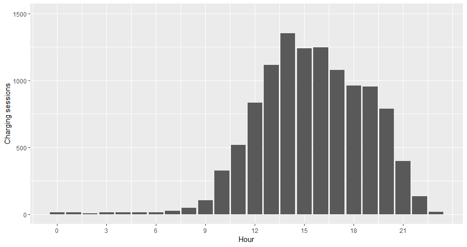

### 2. Ile sesji ładowania się odbyło o godzinie 19?

*wykres radarowy, dane autentyczne*

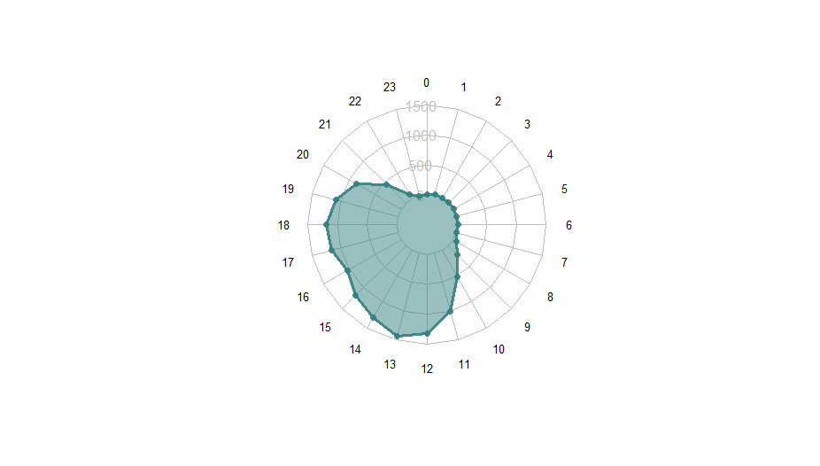

### 3. O której godzinie odbyło się 2 razy więcej sesji niż o 10?

*wykres słupkowy, dane autentyczne*

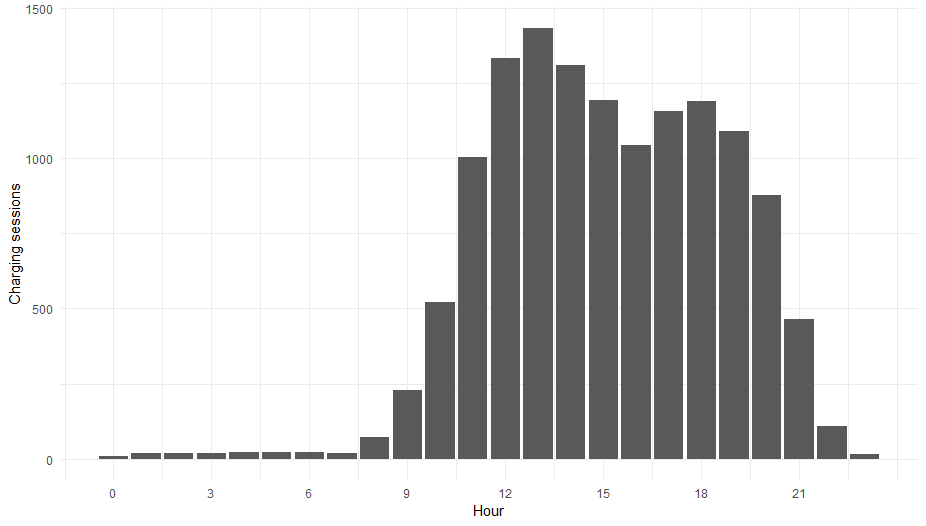

### 4. O której godzinie odbyło się 3 razy więcej sesji niż o 22?

*wykres radarowy, dane sztuczne*

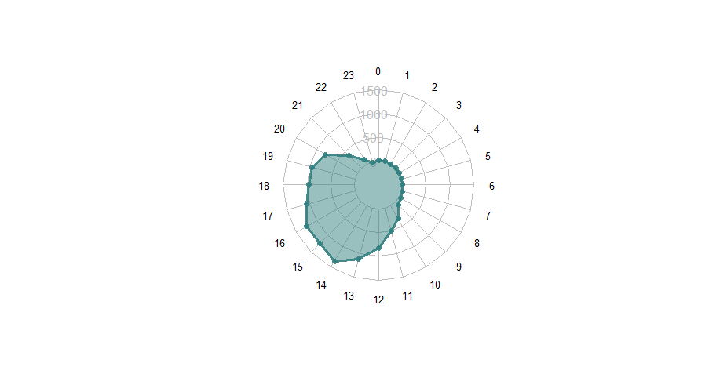

### 5. Który wykres był bardziej estetyczny?

### 6. Z którego wykresu odczyt danych był łatwiejszy?

## Analiza wyników

Udało mi się zgromadzić 67 rozwiązań ankiety, z czego **60** nadających się do dalszej obróbki. Moimi respondentami są użytkownicy serwisu Reddit oraz znajomi w wieku od 14 do 50 lat.

### Zapytania o odczytanie wartości

Okazało się, że błąd w odczytaniu wartości z obu typów wykresów był niewielki. Wartość dokładna dla wykresu słupkowego to 1116 (zaznaczona linią pomarańczową), a dla wykresu radarowego 1098 (zaznaczona linią niebieską). To, że wyniki w przypadku wykresu słupkowego są lekko zawyżone, a dla wykresu radarowego zaniżone najprawdopodobniej spowodowane jest konkretnym wykresem i wcale nie musi być regułą dla danego typu wykresu.

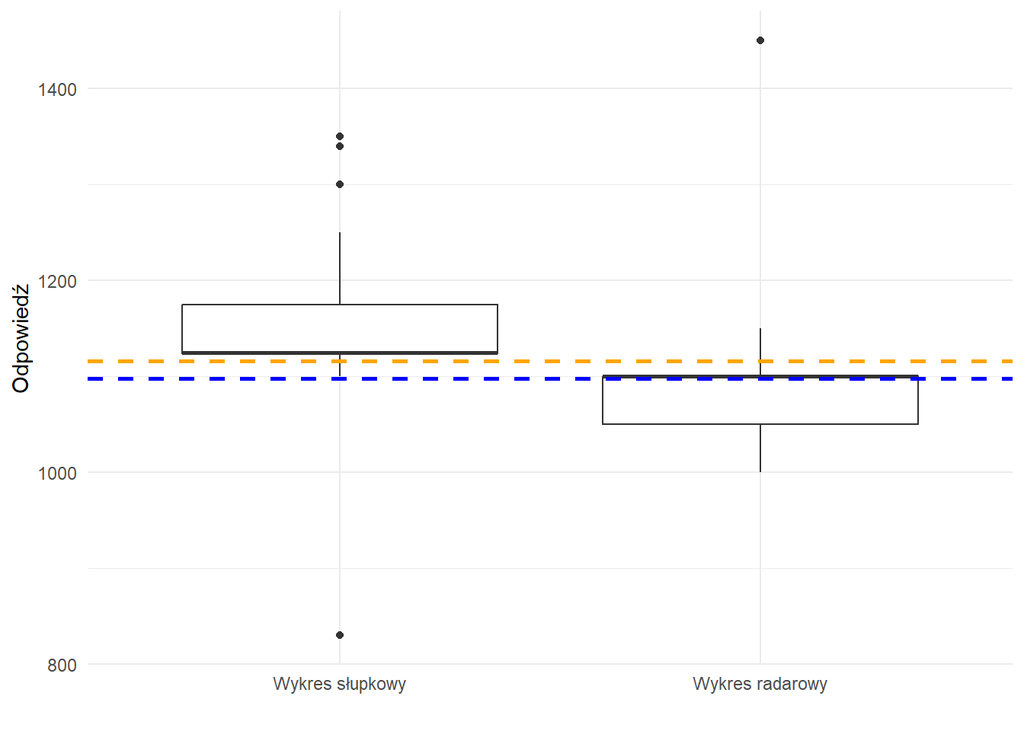

### Zapytania o znalezienie wartości X razy większej

W przypadku wykresu słupkowego odpowiedzi poprawnej (godzina 16) udzieliło 73% osób, co nie powinno być zaskoczeniem.

Ciekawiej sytuacja wygląda w przypadku wykresu radarowego. Odpowiedź poprawną podało jedynie 28% respondentów. Fakt, że oś zaczynała się na okręgu w pewnej odległości od środka radaru, a nie w nim z pewnością wpłynął ujemnie na intuicyjność odczytu.

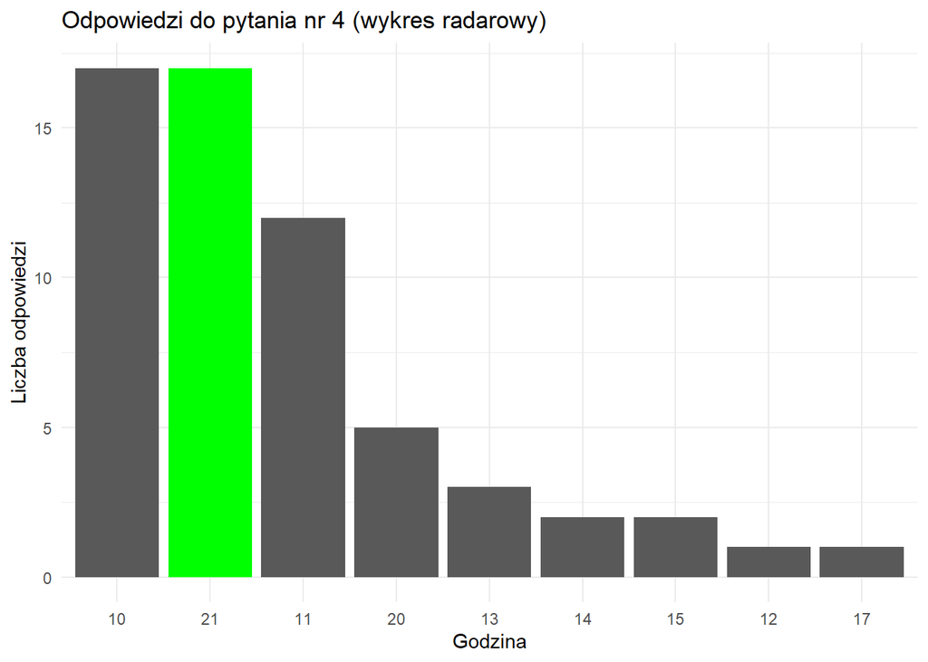

### Pytania zamknięte

Na koniec respondenci zostali zapytani, który wykres bardziej spodobał im się wizualnie oraz który był łatwiejszy w odczycie.

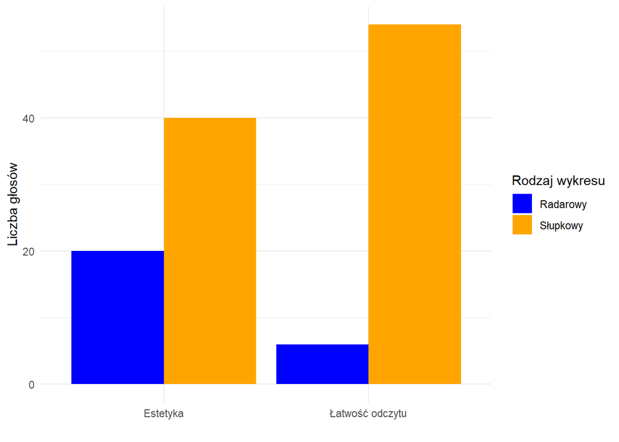

Zdecydowana przewaga wykresu słupkowego z łatwości odczytu nie powinna być zaskoczeniem, jednakże ciekawe jest to, że aż 2/3 ankietowanych uznało wykres słupkowy za bardziej estetyczny